# Aim 2: Cox Models Using SILA-Derived Time to Tau Positivity

## Overview

This analysis fits **Cox proportional hazards models** to examine whether modifiable lifestyle and genetic risk factors predict the estimated age of onset to positivity, derived from SILA models.

**Outcome construction:**

The time scale is **age** (years), allowing survival curves to be interpreted directly as the probability of remaining tau-negative at a given age.

**Two approaches to handle study entry age are shown in parallel:**

1. **Standard** (`Surv(age_last, event)`): treats all participants as entering the risk set at age 0 but can introduce left-truncation bias since participants enroll at different ages.
2. **Left-truncated** (`Surv(age_first, age_last, event)`): counting-process / delayed-entry form. Only the time on study contributes to the risk interval, correcting for differential study entry ages while preserving age as the interpretable time scale.

**Biomarkers:**

- p-tau181
- p-tau217

**Predictors:**

- **CogDrisk risk score** (composite: family history + APOE + CogDrisk burden + GRS burden)
- **LIBRA2 risk score** (composite: family history + APOE + LIBRA2 burden + GRS burden)
- Individual components: APOE ε4 status, family history, GRS (continuous), CogDrisk (continuous), LIBRA2 (continuous)

```r
library(survival)
library(survminer)
library(patchwork)
library(gt)
library(broom)

source('workflow/scripts/config.R')
```

## Load and Prepare Data

```r
# Load SILA individual fits (from PREVENT-AD_SILA.qmd).
# Biomarker positivity thresholds were derived via Youden index ROC analysis in
# PREVENT-AD_PET.qmd and applied within SILA:
#   p-tau181: 6.42 pg/mL
#   p-tau217: 3.06 pg/mL
# The SILA output column estdtt0 encodes time to that threshold, so event/
# censoring is defined entirely from SILA estimates — no PET data needed here.
sila_fits <- read_csv(
  here("results", "Aim1", "tables", "PREVENTAD_SILA_individual_fits.csv"),
  show_col_types = FALSE
)

# Load baseline predictors
baseline_dat <- readRDS(file.path(DATA_CLEANED_PATH, "PREVENTAD_baseline.rds"))
all_dat      <- readRDS(file.path(DATA_CLEANED_PATH, "PREVENTAD_longitudinal.rds"))

cat("SILA fits loaded:", nrow(sila_fits), "observations across",
    n_distinct(sila_fits$subid), "participants\n")
```

```
SILA fits loaded: 1770 observations across 285 participants
```

```r
cat("Biomarkers:", paste(unique(sila_fits$biomarker), collapse = ", "), "\n")
```

```
Biomarkers: ptau181, ptau217
```

```r
# For each participant × biomarker, extract the first and last observation rows.
# Key columns used:
#   val    = last observed biomarker value (event indicator)
#   valt0  = biomarker positivity threshold (Youden cutoff from PET analysis)
#   age_first = age at first biomarker measurement (study entry; left-truncation time)
#   age_last  = age at last biomarker measurement  (exit time / survival time)
# NOTE: aevent is "last" for every row (just a SILA row-type label, not an event
# indicator). estdtt0 is time to threshold from ageref, not from the last visit,
# so estdtt0 <= 0 does not reliably indicate threshold crossing.

# First observation per participant × biomarker (study entry age)
sila_first <- sila_fits %>%
  group_by(subid, biomarker) %>%
  slice_min(age, n = 1, with_ties = FALSE) %>%
  ungroup() %>%
  rename(CONP_ID = subid, age_first = age) %>%
  select(CONP_ID, biomarker, age_first)

# Last observation per participant × biomarker (exit age + event info)
sila_last <- sila_fits %>%
  group_by(subid, biomarker) %>%
  slice_max(age, n = 1, with_ties = FALSE) %>%
  ungroup() %>%
  rename(CONP_ID = subid, age_last = age) %>%
  left_join(sila_first, by = c("CONP_ID", "biomarker"))

cat("Participants per biomarker (last observation):\n")
```

```
Participants per biomarker (last observation):
```

```r
sila_last %>%
  count(biomarker) %>%
  print()
```

```
# A tibble: 2 × 2
  biomarker     n
  <chr>     <int>
1 ptau181     272
2 ptau217     285
```

```r
cat("\nAge range at first observation (study entry):\n")
```

```
Age range at first observation (study entry):
```

```r
sila_last %>%
  group_by(biomarker) %>%
  summarise(
    min_entry = round(min(age_first, na.rm = TRUE), 1),
    mean_entry = round(mean(age_first, na.rm = TRUE), 1),
    max_entry  = round(max(age_first, na.rm = TRUE), 1),
    .groups = "drop"
  ) %>%
  print()
```

```
# A tibble: 2 × 4
  biomarker min_entry mean_entry max_entry
  <chr>         <dbl>      <dbl>     <dbl>
1 ptau181        55.1       63.5      84.2
2 ptau217        55.1       63.5      84.2
```

```r
# Calculate baseline cutoffs from longitudinal data (to avoid data leakage)
baseline_only <- all_dat %>%
  group_by(CONP_ID) %>%
  slice_min(years, n = 1) %>%
  ungroup()

cogdrisk_cutoff_1sd <- mean(baseline_only$score_cogd, na.rm = TRUE) +
                       sd(baseline_only$score_cogd, na.rm = TRUE)
libra2_cutoff_1sd   <- mean(baseline_only$score_libra2, na.rm = TRUE) +
                       sd(baseline_only$score_libra2, na.rm = TRUE)

cat("CogDrisk 1 SD cutoff:", round(cogdrisk_cutoff_1sd, 2), "\n")
```

```
CogDrisk 1 SD cutoff: 7.52
```

```r
cat("LIBRA2 1 SD cutoff:",   round(libra2_cutoff_1sd, 2), "\n")
```

```
LIBRA2 1 SD cutoff: 7.35
```

```r
# Build predictor dataset with risk burden composites
predictors_cox <- baseline_dat %>%
  mutate(
    grs_quartile       = ntile(GRS, 4),
    grs_burden         = if_else(grs_quartile == 4, 1L, 0L),
    fhx_burden         = case_when(str_detect(family_history, "2\\+") ~ 1L, TRUE ~ 0L),
    apoe_burden        = if_else(apoe == "e4+", 1L, 0L),
    cogdrisk_burden    = if_else(score_cogd > cogdrisk_cutoff_1sd, 1L, 0L),
    libra2_burden      = if_else(score_libra2 > libra2_cutoff_1sd, 1L, 0L),
    risk_score_cogd    = fhx_burden + apoe_burden + cogdrisk_burden + grs_burden,
    risk_score_libra2  = fhx_burden + apoe_burden + libra2_burden   + grs_burden,
  ) %>%
  select(CONP_ID, age, sex, educ, apoe, apoe_burden, family_history, fhx_burden,
         GRS, grs_burden, score_cogd, cogdrisk_burden,
         score_libra2, libra2_burden,
         risk_score_cogd, risk_score_libra2)
```

```r
# Join SILA outcomes with predictors
cox_data_full <- sila_last %>%
  left_join(predictors_cox, by = "CONP_ID") %>%
  mutate(
    # Event: last observed biomarker value (val) >= positivity threshold (valt0)
    # Entry time (left-truncation): age at first biomarker observation (age_first)
    # Survival time (exit):
    #   Events   → estaget0: SILA-estimated age at threshold crossing
    #   Censored → age_last: truncate at age of last observed biomarker visit
    #              (do not extrapolate SILA's predicted future onset for negatives)
    event    = if_else(val >= valt0, 1L, 0L),
    surv_age = if_else(val >= valt0 & !is.na(estaget0), estaget0, age_last)
  )

cat("\nCox survival data summary:\n")
```

```
Cox survival data summary:
```

```r
cox_data_full %>%
  group_by(biomarker) %>%
  summarise(
    n            = n(),
    n_events     = sum(event),
    pct_events   = round(mean(event) * 100, 1),
    median_age   = round(median(surv_age, na.rm = TRUE), 1),
    mean_followup = round(mean(surv_age - age_first, na.rm = TRUE), 1),
    .groups = "drop"
  ) %>%
  print()
```

```
# A tibble: 2 × 6
  biomarker     n n_events pct_events median_age mean_followup
  <chr>     <int>    <int>      <dbl>      <dbl>         <dbl>
1 ptau181     272      117       43         62            -2.4
2 ptau217     285       89       31.2       68.7           5
```

## Kaplan-Meier Survival Curves

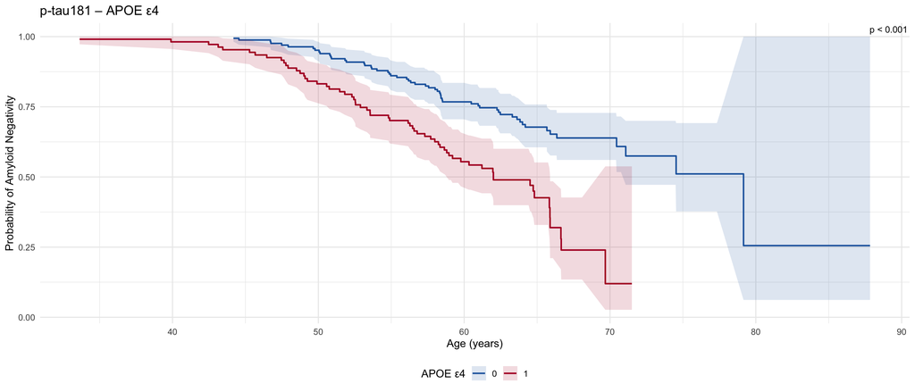

```r
plot_km <- function(data, biomarker_label, group_var, group_label,
                    palette = c("#2166AC", "#B2182B", "#4DAC26", "#D01C8B")) {

  # ggsurvplot has scoping issues with dynamically-built formulae inside
  # functions; use broom::tidy + ggplot2 instead
  km_formula <- as.formula(paste("Surv(surv_age, event) ~", group_var))
  km_fit     <- survfit(km_formula, data = data)

  km_tidy <- broom::tidy(km_fit) %>%
    mutate(strata = gsub(paste0("^", group_var, "="), "", strata))

  # log-rank p-value via base R survdiff (avoids ggsurvplot/survminer scoping issues)
  sd_fit  <- survdiff(km_formula, data = data)
  lr_p    <- pchisq(sd_fit$chisq, df = length(sd_fit$n) - 1, lower.tail = FALSE)
  pval_label <- if (lr_p < 0.001) "p < 0.001" else paste0("p = ", round(lr_p, 3))

  ggplot(km_tidy, aes(x = time, y = estimate, colour = strata, fill = strata)) +
    geom_step(linewidth = 0.8) +
    geom_ribbon(aes(ymin = conf.low, ymax = conf.high), alpha = 0.15, colour = NA) +
    scale_colour_manual(values = palette, name = group_label) +
    scale_fill_manual(values = palette,   name = group_label) +
    annotate("text", x = Inf, y = Inf, hjust = 1.05, vjust = 1.5,
             label = pval_label, size = 3.5) +
    labs(
      title = paste(biomarker_label, "\u2013", group_label),
      x     = "Age (years)",
      y     = "Probability of Amyloid Negativity"
    ) +
    theme_minimal(base_size = 12) +
    theme(legend.position = "bottom")
}

# Split data by biomarker
cox_ptau181 <- cox_data_full %>% filter(biomarker == "ptau181") %>% drop_na(surv_age, event)
cox_ptau217 <- cox_data_full %>% filter(biomarker == "ptau217") %>% drop_na(surv_age, event)

# KM by APOE status
km_181_apoe <- plot_km(cox_ptau181, "p-tau181", "apoe_burden", "APOE ε4")
km_217_apoe <- plot_km(cox_ptau217, "p-tau217", "apoe_burden", "APOE ε4")

print(km_181_apoe)
```

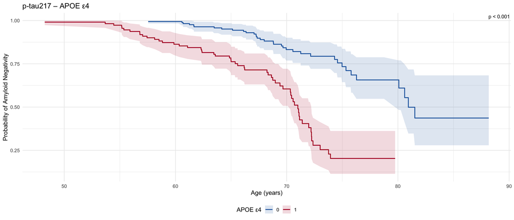

```r
print(km_217_apoe)
```

```r
# Collapse top level to "3+" because only 1 participant has score = 4,
# which is too sparse for survfit to estimate a curve
collapse_risk <- function(x) {
  factor(if_else(x >= 3, "3+", as.character(x)), levels = c("0", "1", "2", "3+"))
}

cox_ptau181 <- cox_ptau181 %>%
  mutate(
    risk_score_cogd_f   = collapse_risk(risk_score_cogd),
    risk_score_libra2_f = collapse_risk(risk_score_libra2)
  )

cox_ptau217 <- cox_ptau217 %>%
  mutate(
    risk_score_cogd_f   = collapse_risk(risk_score_cogd),
    risk_score_libra2_f = collapse_risk(risk_score_libra2)
  )

# 4-colour palette for 0, 1, 2, 3+ risk indicators
palette_5 <- c("0" = "#2166AC", "1" = "#74ADD1", "2" = "#F46D43", "3+" = "#B2182B")

km_181_cogd   <- plot_km(cox_ptau181, "p-tau181", "risk_score_cogd_f",
                          "# of risk indicators (CogDrisk model)", palette = palette_5)
km_181_libra2 <- plot_km(cox_ptau181, "p-tau181", "risk_score_libra2_f",
                          "# of risk indicators (LIBRA2 model)",   palette = palette_5)
km_217_cogd   <- plot_km(cox_ptau217, "p-tau217", "risk_score_cogd_f",
                          "# of risk indicators (CogDrisk model)", palette = palette_5)
km_217_libra2 <- plot_km(cox_ptau217, "p-tau217", "risk_score_libra2_f",
                          "# of risk indicators (LIBRA2 model)",   palette = palette_5)

# 2×2 layout: rows = biomarker, cols = score type
combined <- (km_181_cogd | km_181_libra2) /
(km_217_cogd | km_217_libra2) +
  plot_annotation(
    title = "Kaplan-Meier Curves: Probability of Amyloid Negativity by Composite Risk Score",
    theme = theme(plot.title = element_text(face = "bold", size = 14, hjust = 0.5))
  )

ggsave(file.path(AIM2_OUTPUT_PATH$figures, "1PREVENTAD_combined_plot.png"), combined, width = 14, height = 10, dpi = 300)
```

## Cox Proportional Hazards Models

### Model Specifications

Models are fit separately for each biomarker (p-tau181, p-tau217).

All models use **age** as the time scale, so hazard ratios can be interpreted as the instantaneous probability of crossing the tau positivity threshold at a given age. CogDrisk models are **not** adjusted for age, sex, or education because these are already incorporated into the CogDrisk score itself — adjusting for them would introduce overadjustment. LIBRA2 models **are** adjusted for age, sex, and education because LIBRA2 does not include them.

**Models (M1–M4 + sensitivity M3s):**

- **M1**: Composite CogDrisk risk score (continuous, 0–4), unadjusted
- **M2**: Composite LIBRA2 risk score (continuous, 0–4) + age + sex + education
- **M3** *(primary)*: Individual binary CogDrisk components — APOE ε4, family history (2+ FDR), GRS burden (top quartile). *CogDrisk burden (>1 SD) is excluded from the primary model because the CogDrisk score already embeds age as a component, creating collinearity with the age-based time scale and biasing the HR downward.*
- **M3s** *(sensitivity)*: Same as M3 but including CogDrisk burden — presented for transparency, interpret with caution given age collinearity.
- **M4**: Individual binary LIBRA2 components — APOE ε4, family history (2+ FDR), GRS burden (top quartile), LIBRA2 burden (>1 SD) + age + sex + education
- **M5C**: CogDrisk and GRS as continuous predictors
- **M5L**: LIBRA2 and GRS as continuous predictors

```r
fit_cox_models <- function(data) {

  # Drop rows missing any key variable (applied uniformly across all models)
  dat <- data %>%
    drop_na(surv_age, age_first, event, sex, educ, apoe_burden, fhx_burden,
            GRS, grs_burden, score_cogd, cogdrisk_burden, score_libra2, libra2_burden,
            risk_score_cogd, risk_score_libra2)

  # Two survival objects:
  surv_std <- Surv(dat$surv_age, dat$event)
  surv_lt  <- Surv(dat$age_first, dat$surv_age, dat$event)

  list(
    # ── Standard approach (no left-truncation correction) ────────────────────
    # M1: CogDrisk composite (no age/sex — already embedded in CogDrisk score)
    m1_std  = coxph(surv_std ~ risk_score_cogd,
                    data = dat, ties = "efron"),
    # M2: LIBRA2 composite + age + sex (LIBRA2 does not embed these covariates)
    m2_std  = coxph(surv_std ~ age_last + sex + educ + risk_score_libra2,
                    data = dat, ties = "efron"),
    # M3 primary: individual CogDrisk components excluding cogdrisk_burden
    #   (cogdrisk_burden is excluded because the CogDrisk score already
    #    incorporates age; including it alongside the age-derived time scale
    #    creates collinearity and biases the HR downward)
    m3_std  = coxph(surv_std ~ apoe_burden + fhx_burden + grs_burden,
                    data = dat, ties = "efron"),
    # M3 sensitivity: same as M3 but with cogdrisk_burden included (for
    #   transparency; interpret with caution given age collinearity)
    m3s_std = coxph(surv_std ~ apoe_burden + fhx_burden + grs_burden +
                               cogdrisk_burden,
                    data = dat, ties = "efron"),
    # M4: individual LIBRA2 components + age + sex
    m4_std  = coxph(surv_std ~ age_last + sex + educ + apoe_burden + fhx_burden +
                               grs_burden + libra2_burden,
                    data = dat, ties = "efron"),

    # ── Left-truncated approach (age_first as study entry time) ───────────────
    m1_lt   = coxph(surv_lt ~ risk_score_cogd,
                    data = dat, ties = "efron"),
    m2_lt   = coxph(surv_lt ~ age_last + sex + educ + risk_score_libra2,
                    data = dat, ties = "efron"),
    m3_lt   = coxph(surv_lt ~ apoe_burden + fhx_burden + grs_burden,
                    data = dat, ties = "efron"),
    m3s_lt  = coxph(surv_lt ~ apoe_burden + fhx_burden + grs_burden +
                               cogdrisk_burden,
                    data = dat, ties = "efron"),
    m4_lt   = coxph(surv_lt ~ age_last + sex + educ + apoe_burden + fhx_burden +
                               grs_burden + libra2_burden,
                    data = dat, ties = "efron"),

    # ── M5C / M5L: continuous risk score + continuous GRS ─────────────────────
    # M5C: CogDrisk (continuous) + GRS (continuous) + categorical APOE ε4 + fhx
    #   (not adjusted for age/sex/educ — these are embedded in CogDrisk scoring)
    m5c_std = coxph(surv_std ~ apoe_burden + fhx_burden + GRS + score_cogd,
                    data = dat, ties = "efron"),
    # M5L: LIBRA2 (continuous) + GRS (continuous) + categorical APOE ε4 + fhx
    #   + age + sex + educ (LIBRA2 does not embed these covariates)
    m5l_std = coxph(surv_std ~ age_last + sex + educ + apoe_burden + fhx_burden +
                               GRS + score_libra2,
                    data = dat, ties = "efron"),
    m5c_lt  = coxph(surv_lt ~ apoe_burden + fhx_burden + GRS + score_cogd,
                    data = dat, ties = "efron"),
    m5l_lt  = coxph(surv_lt ~ age_last + sex + educ + apoe_burden + fhx_burden +
                               GRS + score_libra2,
                    data = dat, ties = "efron")
  )
}

models_ptau181 <- fit_cox_models(cox_ptau181)
models_ptau217 <- fit_cox_models(cox_ptau217)
```

```r
# Helper: tidy a Cox model into HR table
# truncation_label: "Standard" or "Left-truncated"
# sensitivity_flag: TRUE for M3s models (cogdrisk_burden included)
tidy_cox <- function(model, biomarker_label, model_label,
                     truncation_label, sensitivity_flag = FALSE) {
  tidy(model, exponentiate = TRUE, conf.int = TRUE) %>%
    mutate(
      biomarker   = biomarker_label,
      model       = model_label,
      truncation  = truncation_label,
      sensitivity = sensitivity_flag,
      p_value     = p.value,
      sig         = case_when(
        p.value < 0.001 ~ "***",
        p.value < 0.01  ~ "**",
        p.value < 0.05  ~ "*",
        p.value < 0.10  ~ ".",
        TRUE            ~ ""
      )
    ) %>%
    select(biomarker, model, truncation, sensitivity,
           term, HR = estimate, conf.low, conf.high, p_value, sig)
}

# ── p-tau181 ─────────────────────────────────────────────────────────────────
results_ptau181 <- bind_rows(
  # Standard
  tidy_cox(models_ptau181$m1_std,  "p-tau181", "M1: CogDrisk Composite",   "Standard"),
  tidy_cox(models_ptau181$m2_std,  "p-tau181", "M2: LIBRA2 Composite",     "Standard"),
  tidy_cox(models_ptau181$m3_std,  "p-tau181", "M3: CogDrisk Components",  "Standard"),
  tidy_cox(models_ptau181$m3s_std, "p-tau181", "M3s: CogDrisk Components (sensitivity)", "Standard",  TRUE),
  tidy_cox(models_ptau181$m4_std,  "p-tau181", "M4: LIBRA2 Components",    "Standard"),
  tidy_cox(models_ptau181$m5c_std, "p-tau181", "M5C: CogDrisk + GRS Continuous", "Standard"),
  tidy_cox(models_ptau181$m5l_std, "p-tau181", "M5L: LIBRA2 + GRS Continuous",   "Standard"),
  # Left-truncated
  tidy_cox(models_ptau181$m1_lt,   "p-tau181", "M1: CogDrisk Composite",   "Left-truncated"),
  tidy_cox(models_ptau181$m2_lt,   "p-tau181", "M2: LIBRA2 Composite",     "Left-truncated"),
  tidy_cox(models_ptau181$m3_lt,   "p-tau181", "M3: CogDrisk Components",  "Left-truncated"),
  tidy_cox(models_ptau181$m3s_lt,  "p-tau181", "M3s: CogDrisk Components (sensitivity)", "Left-truncated", TRUE),
  tidy_cox(models_ptau181$m4_lt,   "p-tau181", "M4: LIBRA2 Components",    "Left-truncated"),
  tidy_cox(models_ptau181$m5c_lt,  "p-tau181", "M5C: CogDrisk + GRS Continuous", "Left-truncated"),
  tidy_cox(models_ptau181$m5l_lt,  "p-tau181", "M5L: LIBRA2 + GRS Continuous",   "Left-truncated")
)

# ── p-tau217 ─────────────────────────────────────────────────────────────────
results_ptau217 <- bind_rows(
  tidy_cox(models_ptau217$m1_std,  "p-tau217", "M1: CogDrisk Composite",   "Standard"),
  tidy_cox(models_ptau217$m2_std,  "p-tau217", "M2: LIBRA2 Composite",     "Standard"),
  tidy_cox(models_ptau217$m3_std,  "p-tau217", "M3: CogDrisk Components",  "Standard"),
  tidy_cox(models_ptau217$m3s_std, "p-tau217", "M3s: CogDrisk Components (sensitivity)", "Standard",  TRUE),
  tidy_cox(models_ptau217$m4_std,  "p-tau217", "M4: LIBRA2 Components",    "Standard"),
  tidy_cox(models_ptau217$m5c_std, "p-tau217", "M5C: CogDrisk + GRS Continuous", "Standard"),
  tidy_cox(models_ptau217$m5l_std, "p-tau217", "M5L: LIBRA2 + GRS Continuous",   "Standard"),
  tidy_cox(models_ptau217$m1_lt,   "p-tau217", "M1: CogDrisk Composite",   "Left-truncated"),
  tidy_cox(models_ptau217$m2_lt,   "p-tau217", "M2: LIBRA2 Composite",     "Left-truncated"),
  tidy_cox(models_ptau217$m3_lt,   "p-tau217", "M3: CogDrisk Components",  "Left-truncated"),
  tidy_cox(models_ptau217$m3s_lt,  "p-tau217", "M3s: CogDrisk Components (sensitivity)", "Left-truncated", TRUE),
  tidy_cox(models_ptau217$m4_lt,   "p-tau217", "M4: LIBRA2 Components",    "Left-truncated"),
  tidy_cox(models_ptau217$m5c_lt,  "p-tau217", "M5C: CogDrisk + GRS Continuous", "Left-truncated"),
  tidy_cox(models_ptau217$m5l_lt,  "p-tau217", "M5L: LIBRA2 + GRS Continuous",   "Left-truncated")
)

all_results <- bind_rows(results_ptau181, results_ptau217)
```

### Results: p-tau181

```r
# Helper to format a single results table (one biomarker, both truncation types,
# primary models only — M3s sensitivity shown separately below)
make_results_table <- function(results_df, biomarker_label) {

  # Primary models only (exclude sensitivity M3s and M5C/M5L — displayed separately)
  primary <- results_df %>%
    filter(!sensitivity, !str_detect(model, "^M5"), !term %in% c("age_last", "sex")) %>%
    mutate(
      hr_fmt = sprintf("%.2f (%.2f\u2013%.2f)%s", HR, conf.low, conf.high, sig),
      p_fmt  = format.pval(p_value, digits = 3, eps = 0.001)
    )

  # Pivot wide: Standard | Left-truncated columns side-by-side
  wide <- primary %>%
    select(model, term, truncation, hr_fmt, p_fmt) %>%
    pivot_wider(
      names_from   = truncation,
      values_from  = c(hr_fmt, p_fmt),
      names_glue   = "{truncation}_{.value}"
    ) %>%
    rename(
      Model                  = model,
      Term                   = term,
      `Standard HR (95% CI)` = `Standard_hr_fmt`,
      `Standard p`           = `Standard_p_fmt`,
      `LT HR (95% CI)`       = `Left-truncated_hr_fmt`,
      `LT p`                 = `Left-truncated_p_fmt`
    )

  wide %>%
    gt() %>%
    tab_header(
      title    = paste("Cox Models:", biomarker_label, "Time to Threshold"),
      subtitle = "Hazard Ratios (95% CI) — Standard vs Left-truncated (LT)"
    ) %>%
    tab_spanner(
      label   = "Standard (Surv(age_last, event))",
      columns = c(`Standard HR (95% CI)`, `Standard p`)
    ) %>%
    tab_spanner(
      label   = "Left-truncated (Surv(age_first, age_last, event))",
      columns = c(`LT HR (95% CI)`, `LT p`)
    ) %>%
    tab_style(
      style     = cell_text(weight = "bold"),
      locations = cells_column_labels()
    ) %>%
    tab_footnote(
      footnote = paste(
        "HR > 1 indicates faster tau positivity onset (earlier age).",
        "M3 excludes CogDrisk burden (age collinearity); see M3s sensitivity table.",
        "* p<0.05; ** p<0.01; *** p<0.001"
      ),
      locations = cells_title()
    )
}

make_m5_table <- function(results_df, biomarker_label) {
  # Rename terms for readability
  term_labels <- c(
    apoe_burden  = "APOE \u03b54 (categorical)",
    fhx_burden   = "Family history \u22652 FDR (categorical)",
    GRS          = "GRS (continuous)",
    score_cogd   = "CogDrisk score (continuous)",
    score_libra2 = "LIBRA2 score (continuous)"
  )

  m5_res <- results_df %>%
    filter(str_detect(model, "^M5"), !term %in% c("age_last", "sex", "educ")) %>%
    mutate(
      term   = recode(term, !!!term_labels),
      hr_fmt = sprintf("%.2f (%.2f\u2013%.2f)%s", HR, conf.low, conf.high, sig),
      p_fmt  = format.pval(p_value, digits = 3, eps = 0.001)
    )

  wide <- m5_res %>%
    select(model, term, truncation, hr_fmt, p_fmt) %>%
    pivot_wider(
      names_from  = truncation,
      values_from = c(hr_fmt, p_fmt),
      names_glue  = "{truncation}_{.value}"
    ) %>%
    rename(
      Model                  = model,
      Term                   = term,
      `Standard HR (95% CI)` = `Standard_hr_fmt`,
      `Standard p`           = `Standard_p_fmt`,
      `LT HR (95% CI)`       = `Left-truncated_hr_fmt`,
      `LT p`                 = `Left-truncated_p_fmt`
    )

  wide %>%
    gt() %>%
    tab_header(
      title    = paste("M5C / M5L:", biomarker_label, "\u2014 Continuous Risk Scores"),
      subtitle = "CogDrisk/LIBRA2 and GRS as continuous predictors; APOE \u03b54 and family history categorical"
    ) %>%
    tab_spanner(
      label   = "Standard (Surv(age_last, event))",
      columns = c(`Standard HR (95% CI)`, `Standard p`)
    ) %>%
    tab_spanner(
      label   = "Left-truncated (Surv(age_first, age_last, event))",
      columns = c(`LT HR (95% CI)`, `LT p`)
    ) %>%
    tab_style(
      style     = cell_text(weight = "bold"),
      locations = cells_column_labels()
    ) %>%
    tab_footnote(
      footnote = paste(
        "M5C: CogDrisk (continuous) + GRS (continuous) + APOE \u03b54 + family history; not adjusted for age/sex/educ (embedded in CogDrisk).",
        "M5L: LIBRA2 (continuous) + GRS (continuous) + APOE \u03b54 + family history + age + sex + educ.",
        "Adjustment covariates (age, sex, educ) omitted from table.",
        "* p<0.05; ** p<0.01; *** p<0.001"
      ),
      locations = cells_title()
    )
}

make_results_table(results_ptau181, "p-tau181")
```

Cox Models: p-tau181 Time to Threshold<sup>1</sup>

Hazard Ratios (95% CI) — Standard vs Left-truncated (LT)<sup>1</sup>

| Model | Term | Standard (Surv(age_last, event)) Standard HR (95% CI) | Standard (Surv(age_last, event)) Standard p | Left-truncated (Surv(age_first, age_last, event)) LT HR (95% CI) | Left-truncated (Surv(age_first, age_last, event)) LT p |
| --- | --- | --- | --- | --- | --- |
| M1: CogDrisk Composite | risk_score_cogd | 1.34 (1.10–1.65)** | 0.00436 | 1.03 (0.48–2.18) | 0.94216 |
| M2: LIBRA2 Composite | sexMale | 1.04 (0.70–1.56) | 0.83008 | 1.00 (0.26–3.89) | 0.99870 |
| M2: LIBRA2 Composite | educ | 1.06 (1.00–1.12)* | 0.03371 | 1.18 (0.99–1.42). | 0.07005 |
| M2: LIBRA2 Composite | risk_score_libra2 | 1.48 (1.19–1.84)*** | < 0.001 | 1.37 (0.58–3.24) | 0.47897 |
| M3: CogDrisk Components | apoe_burden | 2.47 (1.70–3.60)*** | < 0.001 | 2.65 (0.71–9.86) | 0.14728 |
| M3: CogDrisk Components | fhx_burden | 1.06 (0.67–1.66) | 0.80964 | 0.37 (0.05–3.01) | 0.35406 |
| M3: CogDrisk Components | grs_burden | 1.37 (0.91–2.06) | 0.12993 | 2.10 (0.51–8.69) | 0.30464 |
| M4: LIBRA2 Components | sexMale | 1.01 (0.68–1.51) | 0.95718 | 1.01 (0.24–4.29) | 0.99215 |
| M4: LIBRA2 Components | educ | 1.08 (1.02–1.14)* | 0.01152 | 1.19 (0.98–1.44). | 0.08286 |
| M4: LIBRA2 Components | apoe_burden | 2.77 (1.88–4.10)*** | < 0.001 | 6.06 (1.37–26.83)* | 0.01773 |
| M4: LIBRA2 Components | fhx_burden | 1.07 (0.67–1.69) | 0.77905 | 0.20 (0.02–1.95) | 0.16571 |
| M4: LIBRA2 Components | grs_burden | 1.39 (0.92–2.10) | 0.11619 | 3.58 (0.67–19.11) | 0.13514 |
| M4: LIBRA2 Components | libra2_burden | 0.84 (0.49–1.43) | 0.51164 | 0.00 (0.00–Inf) | 0.99871 |

<sup>1</sup> HR > 1 indicates faster tau positivity onset (earlier age). M3 excludes CogDrisk burden (age collinearity); see M3s sensitivity table. * p<0.05; ** p<0.01; *** p<0.001

```r
# Sensitivity table: M3s (with cogdrisk_burden) for both truncation approaches
results_ptau181 %>%
  filter(sensitivity, !term %in% c("age_last", "sex")) %>%
  mutate(
    hr_fmt = sprintf("%.2f (%.2f\u2013%.2f)%s", HR, conf.low, conf.high, sig),
    p_fmt  = format.pval(p_value, digits = 3, eps = 0.001)
  ) %>%
  select(truncation, term, hr_fmt, p_fmt) %>%
  pivot_wider(
    names_from  = truncation,
    values_from = c(hr_fmt, p_fmt),
    names_glue  = "{truncation}_{.value}"
  ) %>%
  rename(
    Term                   = term,
    `Standard HR (95% CI)` = `Standard_hr_fmt`,
    `Standard p`           = `Standard_p_fmt`,
    `LT HR (95% CI)`       = `Left-truncated_hr_fmt`,
    `LT p`                 = `Left-truncated_p_fmt`
  ) %>%
  gt() %>%
  tab_header(
    title    = "p-tau181 — Sensitivity: M3s with CogDrisk Burden",
    subtitle  = "CogDrisk burden included alongside other components (interpret with caution)"
  ) %>%
  tab_spanner(
    label   = "Standard",
    columns = c(`Standard HR (95% CI)`, `Standard p`)
  ) %>%
  tab_spanner(
    label   = "Left-truncated",
    columns = c(`LT HR (95% CI)`, `LT p`)
  ) %>%
  tab_style(
    style     = cell_text(weight = "bold"),
    locations = cells_column_labels()
  ) %>%
  tab_footnote(
    footnote = "CogDrisk burden is collinear with age (age is embedded in CogDrisk scoring); HR may be attenuated. * p<0.05; ** p<0.01; *** p<0.001",
    locations = cells_title()
  )
```

p-tau181 — Sensitivity: M3s with CogDrisk Burden<sup>1</sup>

CogDrisk burden included alongside other components (interpret with caution)<sup>1</sup>

| Term | Standard Standard HR (95% CI) | Standard Standard p | Left-truncated LT HR (95% CI) | Left-truncated LT p |
| --- | --- | --- | --- | --- |
| apoe_burden | 2.45 (1.68–3.56)*** | <0.001 | 2.78 (0.73–10.63) | 0.134 |
| fhx_burden | 1.08 (0.69–1.69) | 0.746 | 0.49 (0.06–4.08) | 0.508 |
| grs_burden | 1.39 (0.92–2.08) | 0.118 | 2.46 (0.55–10.95) | 0.236 |
| cogdrisk_burden | 0.83 (0.50–1.37) | 0.462 | 0.00 (0.00–Inf) | 0.999 |

<sup>1</sup> CogDrisk burden is collinear with age (age is embedded in CogDrisk scoring); HR may be attenuated. * p<0.05; ** p<0.01; *** p<0.001

```r
make_m5_table(results_ptau181, "p-tau181")
```

M5C / M5L: p-tau181 — Continuous Risk Scores<sup>1</sup>

CogDrisk/LIBRA2 and GRS as continuous predictors; APOE ε4 and family history categorical<sup>1</sup>

| Model | Term | Standard (Surv(age_last, event)) Standard HR (95% CI) | Standard (Surv(age_last, event)) Standard p | Left-truncated (Surv(age_first, age_last, event)) LT HR (95% CI) | Left-truncated (Surv(age_first, age_last, event)) LT p |
| --- | --- | --- | --- | --- | --- |
| M5C: CogDrisk + GRS Continuous | APOE ε4 (categorical) | 2.44 (1.67–3.57)*** | <0.001 | 2.46 (0.68–8.94) | 0.1704 |
| M5C: CogDrisk + GRS Continuous | Family history ≥2 FDR (categorical) | 1.07 (0.68–1.69) | 0.7629 | 0.40 (0.05–3.41) | 0.4053 |
| M5C: CogDrisk + GRS Continuous | GRS (continuous) | 1.60 (0.81–3.17) | 0.1757 | 2.73 (0.20–37.25) | 0.4511 |
| M5C: CogDrisk + GRS Continuous | CogDrisk score (continuous) | 0.99 (0.96–1.03) | 0.7518 | 0.97 (0.82–1.15) | 0.7434 |
| M5L: LIBRA2 + GRS Continuous | sexMale | 1.02 (0.68–1.52) | 0.9367 | 1.08 (0.26–4.53) | 0.9183 |
| M5L: LIBRA2 + GRS Continuous | APOE ε4 (categorical) | 2.77 (1.87–4.10)*** | <0.001 | 5.97 (1.28–27.73)* | 0.0226 |
| M5L: LIBRA2 + GRS Continuous | Family history ≥2 FDR (categorical) | 1.08 (0.68–1.71) | 0.7417 | 0.22 (0.02–2.17) | 0.1932 |
| M5L: LIBRA2 + GRS Continuous | GRS (continuous) | 1.77 (0.89–3.52) | 0.1016 | 13.59 (0.53–349.41) | 0.1152 |
| M5L: LIBRA2 + GRS Continuous | LIBRA2 score (continuous) | 0.98 (0.94–1.02) | 0.3579 | 0.94 (0.80–1.11) | 0.4555 |

<sup>1</sup> M5C: CogDrisk (continuous) + GRS (continuous) + APOE ε4 + family history; not adjusted for age/sex/educ (embedded in CogDrisk). M5L: LIBRA2 (continuous) + GRS (continuous) + APOE ε4 + family history + age + sex + educ. Adjustment covariates (age, sex, educ) omitted from table. * p<0.05; ** p<0.01; *** p<0.001

### Results: p-tau217

```r
make_results_table(results_ptau217, "p-tau217")
```

Cox Models: p-tau217 Time to Threshold<sup>1</sup>

Hazard Ratios (95% CI) — Standard vs Left-truncated (LT)<sup>1</sup>

| Model | Term | Standard (Surv(age_last, event)) Standard HR (95% CI) | Standard (Surv(age_last, event)) Standard p | Left-truncated (Surv(age_first, age_last, event)) LT HR (95% CI) | Left-truncated (Surv(age_first, age_last, event)) LT p |
| --- | --- | --- | --- | --- | --- |
| M1: CogDrisk Composite | risk_score_cogd | 1.38 (1.10–1.74)** | 0.00586 | 1.32 (0.98–1.78). | 0.06780 |
| M2: LIBRA2 Composite | sexMale | 1.17 (0.75–1.82) | 0.49314 | 1.12 (0.62–2.00) | 0.71442 |
| M2: LIBRA2 Composite | educ | 1.04 (0.98–1.11) | 0.17695 | 1.05 (0.97–1.14) | 0.20559 |
| M2: LIBRA2 Composite | risk_score_libra2 | 1.72 (1.36–2.18)*** | < 0.001 | 1.53 (1.11–2.11)** | 0.00878 |
| M3: CogDrisk Components | apoe_burden | 4.43 (2.79–7.04)*** | < 0.001 | 2.66 (1.47–4.83)** | 0.00127 |
| M3: CogDrisk Components | fhx_burden | 1.30 (0.79–2.15) | 0.29863 | 1.19 (0.61–2.33) | 0.60660 |
| M3: CogDrisk Components | grs_burden | 1.00 (0.61–1.63) | 0.99238 | 0.91 (0.47–1.76) | 0.77244 |
| M4: LIBRA2 Components | sexMale | 1.08 (0.69–1.70) | 0.72619 | 1.15 (0.64–2.08) | 0.64454 |
| M4: LIBRA2 Components | educ | 1.05 (0.99–1.12). | 0.09935 | 1.06 (0.98–1.15) | 0.11953 |
| M4: LIBRA2 Components | apoe_burden | 4.27 (2.67–6.80)*** | < 0.001 | 2.75 (1.50–5.03)** | 0.00108 |
| M4: LIBRA2 Components | fhx_burden | 1.47 (0.89–2.44) | 0.13265 | 1.27 (0.64–2.50) | 0.49850 |
| M4: LIBRA2 Components | grs_burden | 1.01 (0.62–1.65) | 0.96339 | 0.94 (0.48–1.82) | 0.84658 |
| M4: LIBRA2 Components | libra2_burden | 1.47 (0.87–2.47) | 0.14713 | 1.93 (1.01–3.67)* | 0.04608 |

<sup>1</sup> HR > 1 indicates faster tau positivity onset (earlier age). M3 excludes CogDrisk burden (age collinearity); see M3s sensitivity table. * p<0.05; ** p<0.01; *** p<0.001

```r
results_ptau217 %>%
  filter(sensitivity, !term %in% c("age_last", "sex")) %>%
  mutate(
    hr_fmt = sprintf("%.2f (%.2f\u2013%.2f)%s", HR, conf.low, conf.high, sig),
    p_fmt  = format.pval(p_value, digits = 3, eps = 0.001)
  ) %>%
  select(truncation, term, hr_fmt, p_fmt) %>%
  pivot_wider(
    names_from  = truncation,
    values_from = c(hr_fmt, p_fmt),
    names_glue  = "{truncation}_{.value}"
  ) %>%
  rename(
    Term                   = term,
    `Standard HR (95% CI)` = `Standard_hr_fmt`,
    `Standard p`           = `Standard_p_fmt`,
    `LT HR (95% CI)`       = `Left-truncated_hr_fmt`,
    `LT p`                 = `Left-truncated_p_fmt`
  ) %>%
  gt() %>%
  tab_header(
    title    = "p-tau217 — Sensitivity: M3s with CogDrisk Burden",
    subtitle  = "CogDrisk burden included alongside other components (interpret with caution)"
  ) %>%
  tab_spanner(
    label   = "Standard",
    columns = c(`Standard HR (95% CI)`, `Standard p`)
  ) %>%
  tab_spanner(
    label   = "Left-truncated",
    columns = c(`LT HR (95% CI)`, `LT p`)
  ) %>%
  tab_style(
    style     = cell_text(weight = "bold"),
    locations = cells_column_labels()
  ) %>%
  tab_footnote(
    footnote = "CogDrisk burden is collinear with age (age is embedded in CogDrisk scoring); HR may be attenuated. * p<0.05; ** p<0.01; *** p<0.001",
    locations = cells_title()
  )
```

p-tau217 — Sensitivity: M3s with CogDrisk Burden<sup>1</sup>

CogDrisk burden included alongside other components (interpret with caution)<sup>1</sup>

| Term | Standard Standard HR (95% CI) | Standard Standard p | Left-truncated LT HR (95% CI) | Left-truncated LT p |
| --- | --- | --- | --- | --- |
| apoe_burden | 4.35 (2.74–6.91)*** | < 0.001 | 2.67 (1.47–4.85)** | 0.00124 |
| fhx_burden | 1.38 (0.83–2.27) | 0.21170 | 1.16 (0.59–2.29) | 0.66851 |
| grs_burden | 1.00 (0.61–1.62) | 0.98707 | 0.90 (0.46–1.75) | 0.75694 |
| cogdrisk_burden | 0.65 (0.37–1.13) | 0.12444 | 1.21 (0.61–2.37) | 0.58955 |

<sup>1</sup> CogDrisk burden is collinear with age (age is embedded in CogDrisk scoring); HR may be attenuated. * p<0.05; ** p<0.01; *** p<0.001

```r
make_m5_table(results_ptau217, "p-tau217")
```

M5C / M5L: p-tau217 — Continuous Risk Scores<sup>1</sup>

CogDrisk/LIBRA2 and GRS as continuous predictors; APOE ε4 and family history categorical<sup>1</sup>

| Model | Term | Standard (Surv(age_last, event)) Standard HR (95% CI) | Standard (Surv(age_last, event)) Standard p | Left-truncated (Surv(age_first, age_last, event)) LT HR (95% CI) | Left-truncated (Surv(age_first, age_last, event)) LT p |
| --- | --- | --- | --- | --- | --- |
| M5C: CogDrisk + GRS Continuous | APOE ε4 (categorical) | 4.39 (2.77–6.98)*** | < 0.001 | 2.65 (1.46–4.82)** | 0.00137 |
| M5C: CogDrisk + GRS Continuous | Family history ≥2 FDR (categorical) | 1.35 (0.81–2.25) | 0.24375 | 1.09 (0.56–2.15) | 0.79222 |
| M5C: CogDrisk + GRS Continuous | GRS (continuous) | 1.04 (0.50–2.17) | 0.91921 | 1.02 (0.39–2.64) | 0.97148 |
| M5C: CogDrisk + GRS Continuous | CogDrisk score (continuous) | 0.98 (0.94–1.02) | 0.41978 | 1.04 (0.98–1.11) | 0.16314 |
| M5L: LIBRA2 + GRS Continuous | sexMale | 1.06 (0.67–1.65) | 0.81424 | 1.13 (0.62–2.04) | 0.68849 |
| M5L: LIBRA2 + GRS Continuous | APOE ε4 (categorical) | 4.22 (2.65–6.72)*** | < 0.001 | 2.69 (1.48–4.92)** | 0.00126 |
| M5L: LIBRA2 + GRS Continuous | Family history ≥2 FDR (categorical) | 1.46 (0.88–2.40) | 0.14329 | 1.24 (0.63–2.44) | 0.53146 |
| M5L: LIBRA2 + GRS Continuous | GRS (continuous) | 1.07 (0.51–2.24) | 0.85975 | 0.97 (0.37–2.56) | 0.94685 |
| M5L: LIBRA2 + GRS Continuous | LIBRA2 score (continuous) | 1.02 (0.96–1.07) | 0.51650 | 1.07 (1.00–1.15). | 0.05317 |

<sup>1</sup> M5C: CogDrisk (continuous) + GRS (continuous) + APOE ε4 + family history; not adjusted for age/sex/educ (embedded in CogDrisk). M5L: LIBRA2 (continuous) + GRS (continuous) + APOE ε4 + family history + age + sex + educ. Adjustment covariates (age, sex, educ) omitted from table. * p<0.05; ** p<0.01; *** p<0.001

## Forest Plots

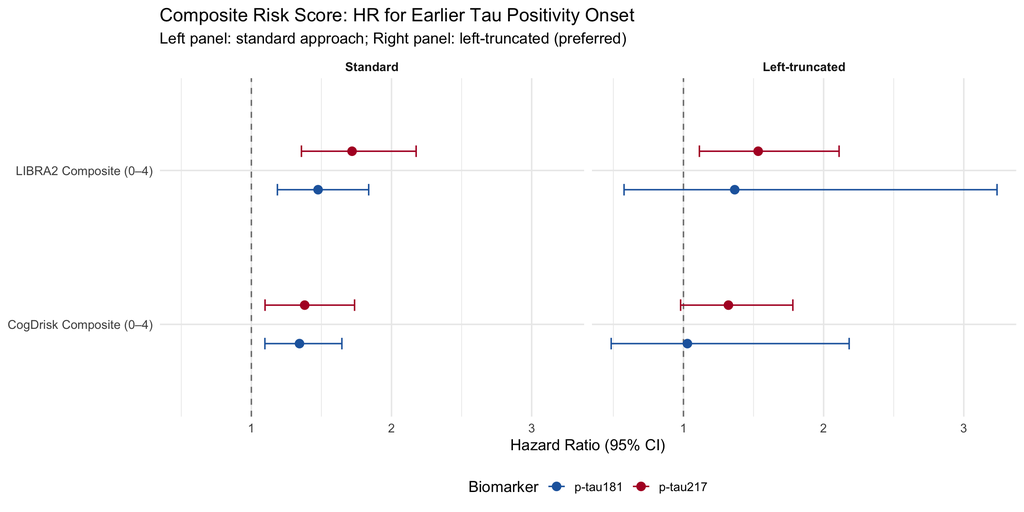

```r
# Focus on composite risk score terms — primary models only, both truncation approaches
forest_composite <- all_results %>%
  filter(term %in% c("risk_score_cogd", "risk_score_libra2"),
         !sensitivity) %>%
  mutate(
    term_label = case_when(
      term == "risk_score_cogd"   ~ "CogDrisk Composite (0\u20134)",
      term == "risk_score_libra2" ~ "LIBRA2 Composite (0\u20134)"
    ),
    biomarker  = factor(biomarker,  levels = c("p-tau181", "p-tau217")),
    truncation = factor(truncation, levels = c("Standard", "Left-truncated"))
  )

ggplot(forest_composite, aes(x = HR, y = term_label, colour = biomarker)) +
  geom_vline(xintercept = 1, linetype = "dashed", colour = "grey50") +
  geom_point(position = position_dodge(width = 0.5), size = 3) +
  geom_errorbarh(aes(xmin = conf.low, xmax = conf.high),
                 height = 0.15,
                 position = position_dodge(width = 0.5)) +
  scale_colour_manual(values = c("p-tau181" = "#2166AC", "p-tau217" = "#B2182B")) +
  facet_wrap(~ truncation, ncol = 2) +
  labs(
    title   = "Composite Risk Score: HR for Earlier Tau Positivity Onset",
    subtitle = "Left panel: standard approach; Right panel: left-truncated (preferred)",
    x       = "Hazard Ratio (95% CI)",
    y       = NULL,
    colour  = "Biomarker"
  ) +
  theme_minimal(base_size = 13) +
  theme(legend.position = "bottom",
        strip.text = element_text(face = "bold"))
```

## Save Results

```r
# Create output directories if needed
dir.create(here("results", "Aim2", "tables"),  recursive = TRUE, showWarnings = FALSE)
dir.create(here("results", "Aim2", "figures"), recursive = TRUE, showWarnings = FALSE)

# Save full results (all truncation approaches + sensitivity models)
write_csv(all_results,
          here("results", "Aim2", "tables", "PREVENTAD_cox_sila_results.csv"))

# Save primary results only (left-truncated, no sensitivity)
all_results %>%
  filter(truncation == "Left-truncated", !sensitivity) %>%
  write_csv(here("results", "Aim2", "tables", "PREVENTAD_cox_sila_results_primary.csv"))

cat("Results saved to:\n")
```

```
Results saved to:
```

```r
cat("- results/Aim2/tables/PREVENTAD_cox_sila_results.csv (all models)\n")
```

```
- results/Aim2/tables/PREVENTAD_cox_sila_results.csv (all models)
```

```r
cat("- results/Aim2/tables/PREVENTAD_cox_sila_results_primary.csv (left-truncated primary only)\n")
```

```
- results/Aim2/tables/PREVENTAD_cox_sila_results_primary.csv (left-truncated primary only)
```